# Preliminary Metabolomics Analysis

Emily Bean

2020-01-10

## Overview

This is the preliminary data analysis for the 15-02 metabolomics dataset, Dr. Connie Rogers lab.

**General cleaning steps:**  
1. Download archived raw .wiff files from Metabolomics Core  
2. Convert .wiff to .mzML in ProteoWizard 4.0 (MS Convert)  
3. Peak picking and alignment in MSDIAL (MoNA database for hydrophilic; LipidBlast for lipids)  
4. Tidy in Excel  
5. Upload to MetaboAnalyst; quantile normalization, Pareto scaling, and log transformation  
6. Download normalized data for statistical analysis in R

**Analysis Steps:**  
1. Individual metabolites 2. Sample clustering  
3. Metabolic “community”

**Pairwise comparisons:**  
*All comparisons made for aqueous (hydrophilic) and lipid data*  
1. Plasma vs. tumor  
2. Plasma D7 vs D21 vd D35  
3. 4 treatment groups (2x2 factorial)  
4. Exercise vs sedentary  
5. Weight gain vs weight maintenance

```r
## Read in all data and load packages
require(dplyr)
require(tidyr)
require(vegan)
require(ggplot2)
require(pairwiseAdonis)
require(ggordiplots)

# read all aqueous data
aq <- read.table("https://raw.githubusercontent.com/EmilyB17/mice-metab/master/data/allAqueousCleaned.txt", header = TRUE, stringsAsFactors = TRUE)

# read all lipids data
lip <- read.table("https://raw.githubusercontent.com/EmilyB17/mice-metab/master/data/allLipidsCleaned.txt", header = TRUE, stringsAsFactors = TRUE)
```

*Summary of the data*  
There are 136 unique metabolites in the aqueous dataset. There are 2434 unique lipids in the lipid dataset. The aqueous metabolites are named, for example:

| Pyruvate |
| --- |
| Alanine.Sacrosine |
| Lactate |
| X2.Oxobutanoate |
| Acetoacetate |
| X3.Hydroxybutyric.acid |
| Serine |
| Glycerate |
| Uracil |
| Proline |

The lipid metabolites are named based on the organic chemistry and bond order. For example:

| FAHFA 23:3; FAHFA 5:0/18:3; [M-H]- |
| --- |
| FAHFA 23:5; FAHFA 20:5/3:0; [M-H]- |
| FAHFA 24:2; FAHFA 18:2/6:0; [M-H]- |
| Cer-AS d35:1+O; Cer-AS d17:1/18:0+O; [M+HCOO]- |
| Cer-BS d43:1+O; Cer-BS d17:1/26:0+O; [M+HCOO]- |
| Cer-AS d33:1+O; Cer-AS d17:1/16:0+O; [M+HCOO]- |
| Cer-AS d34:1+O; Cer-AS d18:1/16:0+O; [M+HCOO]- |
| Cer-ADS d43:1+O; Cer-ADS d16:0/27:1+O; [M-H]- |
| Cer-AP t42:1+O; Cer-AP t26:1/16:0+O; [M+HCOO]- |
| Cer-AS d27:3+O; Cer-AS d15:2/12:1+O; [M-H]- |

**Note:** The `w/o` refers to lipids that had a good match with MS1 but not MS2. These are still usable but we are not as confident in their annotation as we are with the other lipids.  
**Another Note:** These are *annotated metabolites only*. In the raw dataset are many tens of thousands more metabolites and lipids that were detected as compounds but not annotated; we can do a community analysis on these later if we want to.

## Plasma aqueous metabolites through time

It’s important for downstream analysis to first determine if the plasma metabolome change significantly from day 7, to day 21, to day 35. If there are differences, we will need to keep the days separate for downstream analyses; if not, we can likely lump them all together.

An ANOVA on each individual metabolite by Time shows that there are several metabolites that differ between the times, so when analyzing plasma metabolome we will keep Time as a separate factor.

```r
# create a column for the different days

plasmaaq <- aq %>%
  filter(!Label == "tumor") %>%
  mutate(Time = factor(case_when(
    Label %in% "plasmaD7" ~ "7",
    Label %in% "plasmaD21" ~ "21",
    Label %in% "plasmaD35" ~ "35"
  ), ordered = TRUE, levels = c("7", "21", "35")))

# are there differences between time points?
plasmetab <- unique(plasmaaq$metabolite)
pvals <- data.frame()

for(i in 1:length(plasmetab)) {
  mod <- aov(area ~ Time, data = filter(plasmaaq, metabolite == plasmetab[i]))
  pvals[i, "metabolite"] <- plasmetab[i]
  pvals[i, "pval"] <- round(summary(mod)[[1]][["Pr(>F)"]][1], 4)
}

# pull significant p values into a table
sigs <- pvals[pvals$pval < 0.05,]
knitr::kable(sigs)
```

|  | metabolite | pval |
| --- | --- | --- |
| 1 | Pyruvate | 0.0163 |
| 2 | Alanine.Sacrosine | 0.0001 |
| 6 | X3.Hydroxybutyric.acid | 0.0197 |
| 7 | Serine | 0.0098 |
| 9 | Uracil | 0.0242 |
| 11 | Maleic.acid | 0.0440 |
| 17 | Threonine.Homoserine | 0.0389 |
| 19 | Nicotinate | 0.0205 |
| 20 | Taurine | 0.0122 |
| 22 | Pipecolic.Acid | 0.0367 |
| 23 | Citraconic.acid | 0.0144 |
| 26 | N.Acetyl.L.alanine | 0.0059 |
| 28 | Asparagine | 0.0048 |
| 32 | Homocysteine.Methylcysteine | 0.0424 |
| 33 | Anthranilate | 0.0188 |
| 39 | Methionine | 0.0056 |
| 46 | X2.Aminooctanoic.acid | 0.0108 |
| 56 | sn.Glycerol.3.phosphate | 0.0249 |
| 68 | Glucose | 0.0445 |
| 83 | Pantothenate | 0.0008 |
| 85 | Deoxyuridine | 0.0030 |
| 86 | Ribulose.5.phosphate | 0.0446 |
| 88 | Pro.Asp..PD. | 0.0124 |
| 90 | Uridine | 0.0239 |
| 99 | Xanthosine | 0.0005 |
| 113 | AMP | 0.0450 |
| 127 | FMN | 0.0106 |

A post-hoc Tukey’s test shows where the differences lie between days.

```r
sigdf <- plasmaaq[plasmaaq$metabolite %in% sigs$metabolite, ]

# perform ANOVA again and store Tukey variables
metabs <- unique(sigdf$metabolite)
tukeyOut <- data.frame()

for(i in 1:length(metabs)) {
  # re-run the ANOVA
  mod <- aov(area ~ Time, data = filter(sigdf, metabolite == metabs[i]))
  # perform Tukey post-hoc test and store significant p values
  tuk <- TukeyHSD(mod)
  tukmat <- tuk$Time
  sig <- data.frame(p = round(tukmat[,"p adj"], 4),
                    contrast = dimnames(tukmat)[[1]])


  ## workaround for if Tukey does not show significance but ANOVA does:
  if(any(sig$p < 0.05)) {

    sigsdf <- sig[sig$p < 0.05, ]
    sigsdf$metabolite <- metabs[i]
  } else {

    sigsdf <- data.frame(p = "error",
                       contrast = "error",
                       metabolite = metabs[i])

  }


  # append to outDF
  tukeyOut <- rbind(tukeyOut, sigsdf)
}



rownames(tukeyOut) <- NULL
tukeyOut <- tukeyOut[!tukeyOut$p %in% "error",]

knitr::kable(tukeyOut)
```

|  | p | contrast | metabolite |
| --- | --- | --- | --- |
| 1 | 0.0187 | 35-21 | Pyruvate |
| 2 | 1e-04 | 35-7 | Alanine.Sacrosine |
| 3 | 0.0131 | 35-21 | Alanine.Sacrosine |
| 4 | 0.0255 | 35-7 | X3.Hydroxybutyric.acid |
| 5 | 0.0068 | 35-7 | Serine |
| 6 | 0.0335 | 35-21 | Uracil |
| 8 | 0.0298 | 35-7 | Threonine.Homoserine |
| 9 | 0.0264 | 21-7 | Nicotinate |
| 10 | 0.0177 | 35-21 | Taurine |
| 12 | 0.0311 | 35-7 | Citraconic.acid |
| 13 | 0.0353 | 35-21 | Citraconic.acid |
| 14 | 0.0069 | 35-7 | N.Acetyl.L.alanine |
| 15 | 0.0483 | 35-21 | N.Acetyl.L.alanine |
| 16 | 0.0032 | 35-7 | Asparagine |
| 17 | 0.0353 | 35-7 | Homocysteine.Methylcysteine |
| 18 | 0.0431 | 35-7 | Anthranilate |
| 19 | 0.0393 | 35-21 | Anthranilate |
| 20 | 0.0099 | 35-7 | Methionine |
| 21 | 0.0257 | 35-21 | Methionine |
| 22 | 0.0194 | 35-7 | X2.Aminooctanoic.acid |
| 23 | 0.0369 | 35-21 | X2.Aminooctanoic.acid |
| 24 | 0.0201 | 35-21 | sn.Glycerol.3.phosphate |
| 26 | 0.0014 | 35-7 | Pantothenate |
| 27 | 0.0084 | 35-21 | Pantothenate |
| 28 | 0.0026 | 35-7 | Deoxyuridine |
| 30 | 0.0116 | 35-7 | Pro.Asp..PD. |
| 31 | 0.0249 | 35-7 | Uridine |
| 32 | 3e-04 | 21-7 | Xanthosine |
| 33 | 0.0453 | 35-7 | AMP |
| 34 | 0.0128 | 21-7 | FMN |
| 35 | 0.0477 | 35-7 | FMN |

We can also visualize the difference by using boxplots

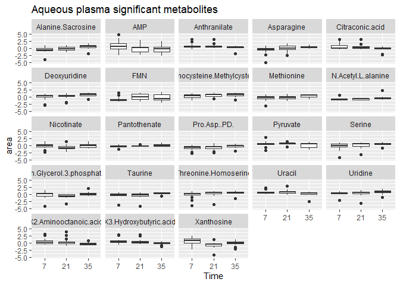

```r
## make boxplots to illustrate differences

tukdf <- plasmaaq[plasmaaq$metabolite %in% tukeyOut$metabolite, ]

ggplot(data = tukdf, aes(x = Time, y = area)) +
  geom_boxplot() +
  facet_wrap(~metabolite) +
  ggtitle("Aqueous plasma significant metabolites")
```

[output not shown]

## Individual Metabolites

#### Four treatment groups

The initial analyis is comparing all four treatment groups to each other in the 2x2 factorial style. The code follows this structure for pairwise comparisons with ANOVA:

> This code is a one-way ANOVA between the area under the curve (dependent variable) and the four treatment groups (independent variable) for the tumor tissue only. This ANOVA repeats in a “for loop” for all 136 aqueous metabolites, and stores the p values in a table.

##### Tumor tissue - aqueous

There are four significant metabolites; that is, four metabolites vary significantly between the four treatment groups in the tumor tissue.

```r
### TUMOR

# make separate dataframe for the tumor tissue
tumor <- filter(aq, Label == "tumor")
metabs <- levels(tumor$metabolite)

pvals <- data.frame()

# run the for loop
for(i in 1:length(metabs)) {
  mod <- aov(area ~ treatmentID, data = filter(tumor, metabolite == metabs[i]))
  pvals[i, "metabolite"] <- metabs[i]
  pvals[i, "pval"] <- round(summary(mod)[[1]][["Pr(>F)"]][1], 4)

}

# pull significant p values into a table
sigs <- pvals[pvals$pval < 0.05,]
knitr::kable(sigs, col.names =  c("metabolite", "p value"))
```

|  | metabolite | p value |
| --- | --- | --- |
| 2 | Acetyl.aspartate | 0.0202 |
| 45 | Glucose | 0.0069 |
| 58 | Hydroxyproline.Aminolevulinate | 0.0188 |
| 91 | Quinolinate | 0.0054 |

##### Tumor tissue - lipids

There are many more annotated lipids than there are aqueous metabolites, so it may not be as productive to analyze each individual lipid. For initial analysis, we will look at each annotated lipid and see what may be important for later analysis in functional groups.

```r
### TUMOR

# make separate dataframe for the tumor tissue
tumor <- filter(lip, tissue.type == "tumor")
metabs <- levels(tumor$lipid)

pvals <- data.frame()

# run the for loop
for(i in 1:length(metabs)) {
  mod <- aov(log.area ~ treatmentID, data = filter(tumor, lipid == metabs[i]))
  pvals[i, "lipid"] <- metabs[i]
  pvals[i, "pval"] <- round(summary(mod)[[1]][["Pr(>F)"]][1], 4)

}

# pull significant p values into a table
sigs <- pvals[pvals$pval < 0.05,]
#knitr::kable(sigs, col.names =  c("metabolite", "p value"))
```

##### Plasma – aqueous

Since we clearly saw that there is a difference in the plasma aqueous metabolites between days (above), we will keep Time as a separate factor moving forward. Three separate ANOVAs; one for each time point.

```r
# get metabolites

metabs <- levels(plasmaaq$metabolite)

pvals <- data.frame()

# run the for loop
for(i in 1:length(metabs)) {
  mod1 <- aov(area~ treatmentID, data = filter(plasmaaq, metabolite == metabs[i] & Time == "7"))
  pvals[i, "metabolite"] <- metabs[i]
  pvals[i, "pvalD7"] <- round(summary(mod1)[[1]][["Pr(>F)"]][1], 4)
  mod2 <- aov(area~ treatmentID, data = filter(plasmaaq, metabolite == metabs[i] & Time == "21"))
  pvals[i, "pvalD21"] <- round(summary(mod2)[[1]][["Pr(>F)"]][1], 4)
  mod3 <- aov(area~ treatmentID, data = filter(plasmaaq, metabolite == metabs[i] & Time == "35"))
  pvals[i, "pvalD35"] <- round(summary(mod3)[[1]][["Pr(>F)"]][1], 4)

}

sigs <- pvals[pvals[,2:4] < 0.05, ] %>% na.omit()
```

##### Plasma –lipids

```r
# make separate dataframe for lipid
plasmalip <- lip %>%
  filter(tissue.type == "plasma") %>%
  mutate(SampleName = as.character(SampleName))

for(i in 1:nrow(plasmalip)) {
  plasmalip[i, "Time"] <- strsplit(plasmalip$SampleName[i], "_")[[1]][1]
}

lipids <- unique(plasmalip$lipid)
pvals <- data.frame()

# run the for loop
for(i in 1:length(lipids)) {
  mod1 <- aov(log.area~ treatmentID, data = filter(plasmalip, lipid == lipids[i] & Time == "D7"))
  pvals[i, "lipid"] <- lipids[i]
  pvals[i, "pvalD7"] <- round(summary(mod1)[[1]][["Pr(>F)"]][1], 4)
  mod2 <- aov(log.area~ treatmentID, data = filter(plasmalip, lipid == lipids[i] & Time == "D21"))
  pvals[i, "pvalD21"] <- round(summary(mod2)[[1]][["Pr(>F)"]][1], 4)
  mod3 <- aov(log.area~ treatmentID, data = filter(plasmalip, lipid == lipids[i] & Time == "D35"))
  pvals[i, "pvalD35"] <- round(summary(mod3)[[1]][["Pr(>F)"]][1], 4)

}

sigs <- pvals[pvals[,2:4] < 0.05, ] %>% na.omit()
```

## Community Analysis

Another way of analyzing this data is to treat all of the metabolites in a sample as a community and look at differences between the “metabolomes” of each sample.

### Non-metric multidimensional scaling (NMDS)

NMDS plots each sample by its similarity to the community of another sample. The statistical test is a permutational ANOVA to determine statistical differences between treatment groups. In theory, you can visually see statistical significance on the NMDS plot when two ellipses are separate from each other. In practice, this doesn’t always happen because ordinations are performed in multiple dimensions and reduced to 2D for visualization, so keep that in mind.